# mlassign2

```python
import pandas as pd
import numpy as np
from sklearn.preprocessing import StandardScaler
from sklearn.linear_model import LinearRegression
from sklearn.metrics import mean_squared_error
from sklearn.metrics import r2_score
from sklearn.metrics import explained_variance_score
from sklearn.model_selection import train_test_split
```

```python
bot = pd.read_csv('bottle.csv')
```

```python
bot = bot[['T_degC','Salnty','STheta','O2ml_L','Depthm']]
```

```python
bot.head()
```

|  | T_degC | Salnty | STheta | O2ml_L | Depthm |
| --- | --- | --- | --- | --- | --- |
| 0 | 10.50 | 33.440 | 25.649 | NaN | 0 |
| 1 | 10.46 | 33.440 | 25.656 | NaN | 8 |
| 2 | 10.46 | 33.437 | 25.654 | NaN | 10 |
| 3 | 10.45 | 33.420 | 25.643 | NaN | 19 |
| 4 | 10.45 | 33.421 | 25.643 | NaN | 20 |

```python
bot.info()
```

```
<class 'pandas.core.frame.DataFrame'>
RangeIndex: 864863 entries, 0 to 864862
Data columns (total 5 columns):
 #   Column  Non-Null Count   Dtype
---  ------  --------------   -----
 0   T_degC  853900 non-null  float64
 1   Salnty  817509 non-null  float64
 2   STheta  812174 non-null  float64
 3   O2ml_L  696201 non-null  float64
 4   Depthm  864863 non-null  int64
dtypes: float64(4), int64(1)
memory usage: 33.0 MB
```

```python
bot = bot.dropna()
```

```python
bot.info()
```

```
<class 'pandas.core.frame.DataFrame'>
Index: 661268 entries, 2160 to 864862
Data columns (total 5 columns):
 #   Column  Non-Null Count   Dtype
---  ------  --------------   -----
 0   T_degC  661268 non-null  float64
 1   Salnty  661268 non-null  float64
 2   STheta  661268 non-null  float64
 3   O2ml_L  661268 non-null  float64
 4   Depthm  661268 non-null  int64
dtypes: float64(4), int64(1)
memory usage: 30.3 MB
```

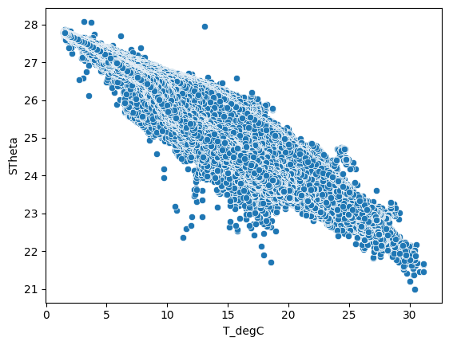

```python
import seaborn as sns
sns.scatterplot(y='STheta',x = "T_degC", data=bot)
```

```python
bot = bot.reset_index(drop = True)
```

```python
X = bot.drop('T_degC',axis=1)
y = bot['T_degC']
```

```python
y = np.reshape(y, (661268,1))
y.shape
```

```
(661268, 1)
```

```python
X.head()
```

|  | Salnty | STheta | O2ml_L | Depthm |
| --- | --- | --- | --- | --- |
| 0 | 33.030 | 25.364 | 5.90 | 0 |
| 1 | 32.920 | 23.568 | 6.02 | 6 |
| 2 | 32.951 | 25.304 | 6.04 | 10 |
| 3 | 32.990 | 25.335 | 6.06 | 15 |
| 4 | 33.005 | 25.339 | 6.04 | 20 |

```python
scaler = StandardScaler()
X_train, X_test, y_train, y_test = train_test_split(X, y, test_size = 0.2, random_state=42)
X_train_scaled = scaler.fit_transform(X_train)
X_test_scaled = scaler.transform(X_test)
```

```python
lin_reg = LinearRegression()
```

```python
model = lin_reg.fit(X_train_scaled, y_train)
y_pred_sklearn = model.predict(X_test_scaled)
```

```python
y_pred_sklearn
```

```
array([[16.68352894],
       [ 8.63573844],
       [10.70717149],
       ...,
       [ 6.18878341],
       [10.95304487],
       [16.36582647]])
```

```python
model.coef_
```

```
array([[ 1.63046569, -4.6345913 ,  0.3020677 , -0.47495536]])
```

```python
model.intercept_
```

```
array([10.91541795])
```

```python
mean_squared_error(y_test, y_pred_sklearn)
```

```
0.11101117205433632
```

```python
r2_score(y_test, y_pred_sklearn)
```

```
0.9937682503632342
```

```python
explained_variance_score(y_test, y_pred_sklearn)
```

```
0.9937684088237414
```

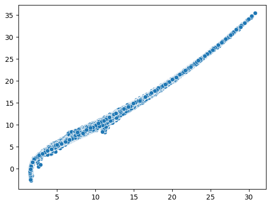

```python
#sns.scatterplot(y_test,y_pred_sklearn)
sns.scatterplot( x=[x[0] for x in y_test], y=[x[0] for x in y_pred_sklearn])
```

```python
X_train_scaled = np.c_[np.ones((X_train_scaled.shape[0], 1)), X_train_scaled]
X_test_scaled = np.c_[np.ones((X_test_scaled.shape[0], 1)), X_test_scaled]
```

```python
X_train_scaled.shape
```

```
(529014, 5)
```

```python
X_train_scaled
```

```
array([[ 1.        , -0.94801805, -0.33072186,  0.80884944, -0.22441603],
       [ 1.        ,  0.62640206,  0.87719897, -0.85837645,  0.31487462],
       [ 1.        , -1.39537053, -0.99210802,  1.19062   , -0.61604377],
       ...,
       [ 1.        , -1.05659875, -1.19705852,  1.15195969, -0.6481444 ],
       [ 1.        ,  1.45595859,  1.4712584 , -1.53009935,  1.86212518],
       [ 1.        , -1.39537053,  0.18511974,  1.11329938, -0.30787768]])
```

```python
theta_path_mgd = []
n_iterations = 100
minibatch_size = 50
eta = 0.1
np.random.seed(42)
theta = np.random.randn(5,1)
m = len(X_train_scaled)
for epoch in range(n_iterations):
    shuffled_indices = np.random.permutation(m)
    X_train_shuffled = X_train_scaled[shuffled_indices]
    y_shuffled = y_train[shuffled_indices]
    for i in range(0, m, minibatch_size):
        xi = X_train_shuffled[i:i+minibatch_size]
        yi = y_shuffled[i:i+minibatch_size]
        gradients = 2/minibatch_size * xi.T.dot(xi.dot(theta) - yi)
        theta = theta - eta * gradients
        theta_path_mgd.append(theta)
```

```python
preds = X_test_scaled.dot(theta)
```

```python
preds
```

```
array([[16.75436897],
       [ 8.62661748],
       [10.6922259 ],
       ...,
       [ 6.21176543],
       [10.98615343],
       [16.43806937]])
```

```python
print(mean_squared_error(y_test, preds))
print(r2_score(y_test, preds))
print(explained_variance_score(y_test, preds))
```

```
0.11849098415821005
0.993348361846621
0.9934025353594004
```

```python
print(mean_squared_error(y_train, train_preds))
print(r2_score(y_train, train_preds))
print(explained_variance_score(y_train, train_preds))
```

[output not shown]

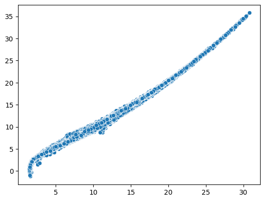

```python
sns.scatterplot( x=[x[0] for x in y_test], y=[x[0] for x in preds])
```

```python
theta_path_mgd = []
n_iterations = 100
minibatch_size = 250
eta = 0.1
np.random.seed(42)
theta = np.random.randn(5,1)
m = len(X_train_scaled)
for epoch in range(n_iterations):
    shuffled_indices = np.random.permutation(m)
    X_train_shuffled = X_train_scaled[shuffled_indices]
    y_shuffled = y_train[shuffled_indices]
    for i in range(0, m, minibatch_size):
        xi = X_train_shuffled[i:i+minibatch_size]
        yi = y_shuffled[i:i+minibatch_size]
        gradients = 2/minibatch_size * xi.T.dot(xi.dot(theta) - yi)
        theta = theta - eta * gradients
        theta_path_mgd.append(theta)
```

```python
preds = X_test_scaled.dot(theta)
preds
```

```
array([[16.69509324],
       [ 8.63346942],
       [10.70154855],
       ...,
       [ 6.22110695],
       [10.96188625],
       [16.37869776]])
```

```python
print(mean_squared_error(y_test, preds))
print(r2_score(y_test, preds))
print(explained_variance_score(y_test, preds))
```

```
0.11258212760466284
0.993680062827701
0.9936901617520404
```

```python
print(mean_squared_error(y_train, train_preds))
print(r2_score(y_train, train_preds))
print(explained_variance_score(y_train, train_preds))
```

[output not shown]

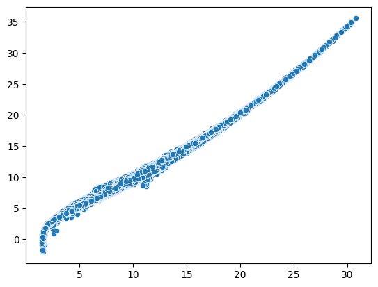

```python
sns.scatterplot( x=[x[0] for x in y_test], y=[x[0] for x in preds])
```

```python
theta_path_mgd = []
n_iterations = 100
minibatch_size = 2000
eta = 0.1
np.random.seed(42)
theta = np.random.randn(5,1)
m = len(X_train_scaled)
for epoch in range(n_iterations):
    shuffled_indices = np.random.permutation(m)
    X_train_shuffled = X_train_scaled[shuffled_indices]
    y_shuffled = y_train[shuffled_indices]
    for i in range(0, m, minibatch_size):
        xi = X_train_shuffled[i:i+minibatch_size]
        yi = y_shuffled[i:i+minibatch_size]
        gradients = 2/minibatch_size * xi.T.dot(xi.dot(theta) - yi)
        theta = theta - eta * gradients
        theta_path_mgd.append(theta)
```

```python
preds = X_test_scaled.dot(theta)
preds
```

```
array([[16.67632637],
       [ 8.63419781],
       [10.70549328],
       ...,
       [ 6.20197517],
       [10.95015388],
       [16.35892204]])
```

```python
print(mean_squared_error(y_test, preds))
print(r2_score(y_test, preds))
print(explained_variance_score(y_test, preds))
```

```
0.11108234889743424
0.9937642547629905
0.9937642566494848
```

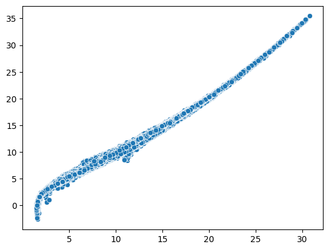

```python
sns.scatterplot( x=[x[0] for x in y_test], y=[x[0] for x in preds])
```

```python
X_train_scaled.shape
```

```
(529014, 5)
```

```python
train_preds = X_train_scaled.dot(theta)
train_preds
```

```
array([[11.24802176],
       [ 7.46855598],
       [13.88163369],
       ...,
       [15.38982215],
       [ 5.1451295 ],
       [ 8.25388011]])
```

```python
print(mean_squared_error(y_train, train_preds))
print(r2_score(y_train, train_preds))
print(explained_variance_score(y_train, train_preds))
```

```
0.1107041812493561
0.9937997504958369
0.9937999455871723
```

Conceptual Questions

1. Describe how parameter estimation in Gradient Descent differs from using the normal equation.

Gradient Descent comprises parameters like Theta, Learning rate as opposed to the coefficients and intercept used for linear regression. It is more of an optimisation method compared to normal equation. Normal equation would only work on linear data whereas GD works on linear as well as non-linear data. Unlike Gradient Descent, the normal equation provides the global minimum of the cost function for linear regression problems and it is also computationally expensive for large datasets.

3. Identify your best-performing version of Gradient Descent and compare the error metrics for test data vs training data. Does this version of gradient descent show signs of overfitting? Explain.

The most effective model we've found utilizes a mini-batch size of 2000. It exhibits the lowest error on the test set and achieves the highest explained variance and R2 values. Importantly, it doesn't appear to suffer from overfitting, as indicated by the fact that the root mean squared error (RMSE) on the training set is only slightly lower and remains comparable to that of the test set. This suggests that the model generalizes well beyond the training data.

4. Explain what the learning rate is for. Even though we did not, why might it be helpful to change the learning rate over time?

The learning rate plays a crucial role in determining how quickly the algorithm converges to the minimum of the cost function. It essentially controls the step size taken in each iteration of the gradient descent process.The learning rate would depend on the slope of the curve and also the cost function. If we see that our cost function is somehow increasing instead of decreasing, we need to increase the learning rate and vice versa.

5. Why would a data scientist want to use early stopping in gradient descent?

Early stopping means stopping gradient descent when the validation error starts to increase. This indicates that it is applied to prevent overfitting. It also streamlines the model selection process by providing a clear criterion for determining the optimal stopping point